# Models in science

MCSB Bootcamp — Mathematical and Computational Track

Jun Allard

# What a model is

## Coffee bean titration

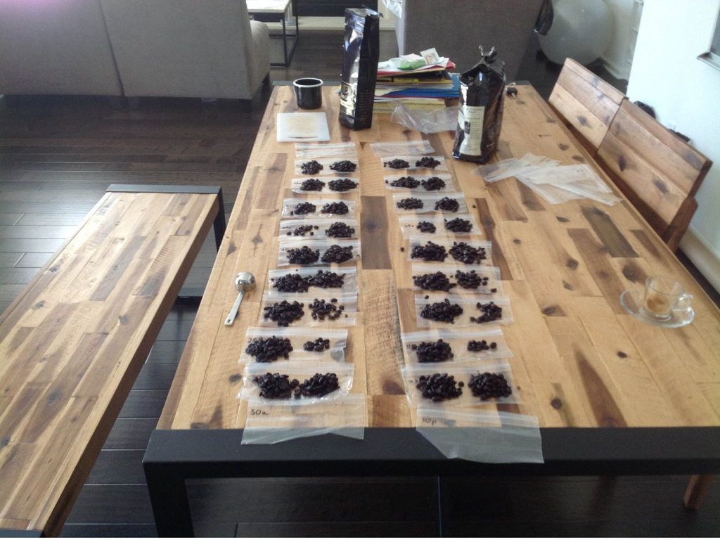

## Coffee bean dynamical system

[figure not shown]

## Coffee bean strategy

Coffee beans, measuring each aliquot and titrating it in carefully. Mixing the two gradually. So I guess at day 10 it should be at 50%.

Model

Behavior

```python
N = 10  # number of scoops in each jar
n_max = 2 * N  # max number of days to simulate

x = np.zeros(n_max)  # fraction caffeinated
x[0] = 1.0  # initial fraction caffeinated

for n in range(1, n_max):

    x[n] = (1 - 1 / N) * x[n - 1]

# finished loop through days

days = np.arange(1, n_max + 1)

fig, ax = plt.subplots()
ax.plot(days, x, "-ok")
ax.set_ylabel("Fraction caffeinated")
ax.set_xlabel("Days")
plt.show()
```

[figure not shown]

Figure 1: Fraction of the jar still caffeinated, day by day, for a ten-scoop jar.

## What a model is

[figure not shown]

- A model takes model parameters and assumptions and leads to an inevitable predicted behavior.
- (“Inevitable” does not mean deterministic. Can be stochastic.)
- The input assumptions can be imperfect.
- The output can be counter-intuitive and surprising.
- It’s not always time that separates inputs from outputs.

## Barnhart et al., 2016

[figure not shown]

## Story, setting, characters traits, and plotline

[figure not shown]

Inevitability is what makes it useful as a hypothesis-rejection tool.

Why might you do this?

[figure not shown]

Reason 1: *Perturbable predictive understanding of the world*

“If someone changes *this*, then the biological system will do *this*.”

This is what is needed for modern engineering practices to be brought to biomedical and biotech.

## Models in MCSB

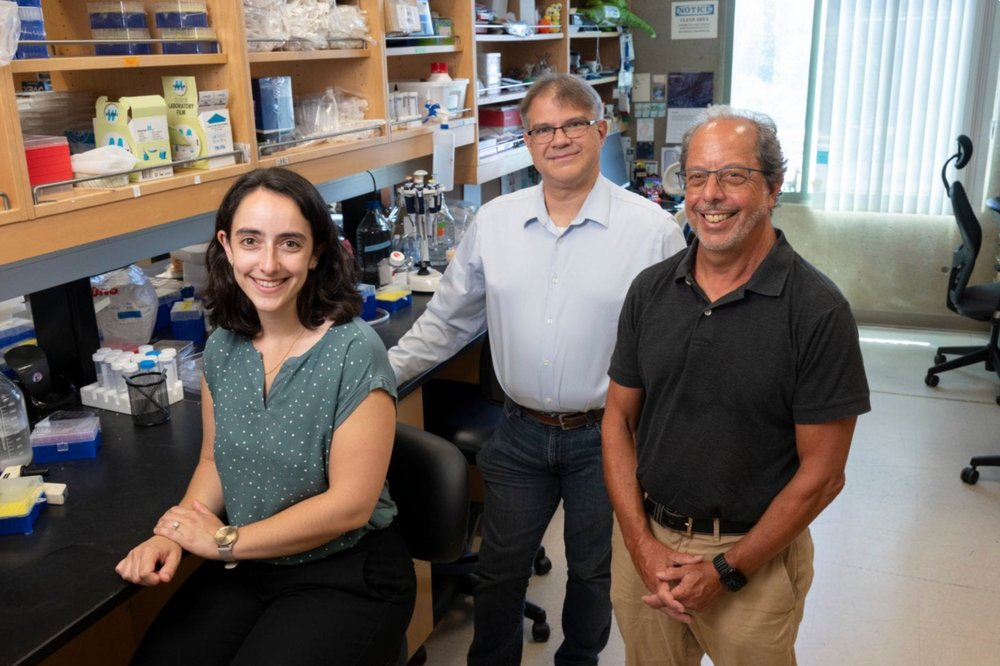

Sousa (MCSB 2026) et al. *Cancer Research*, 2026

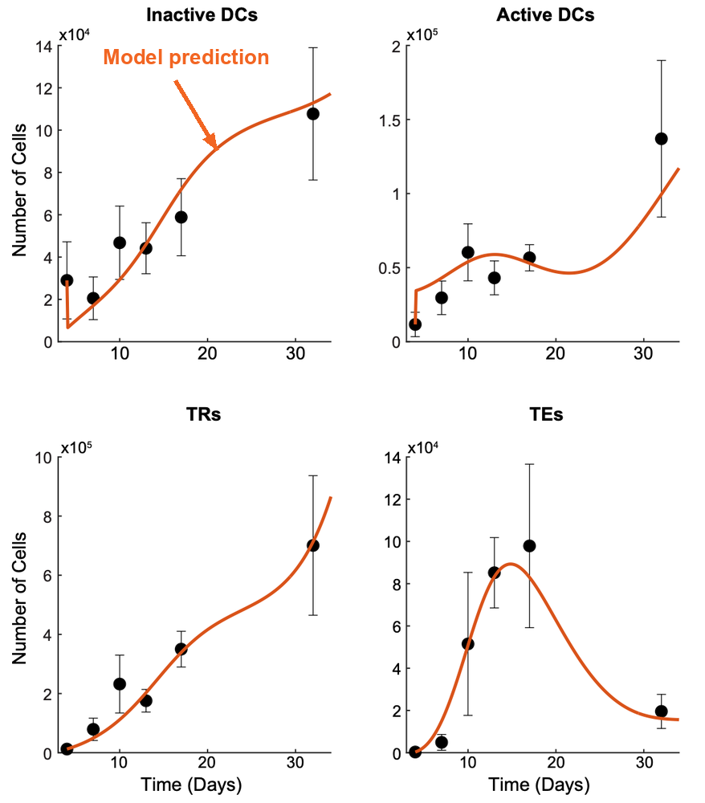

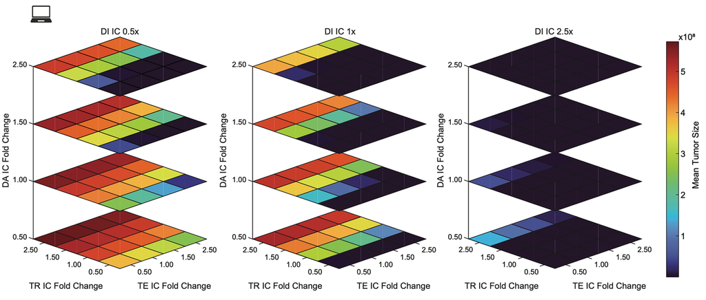

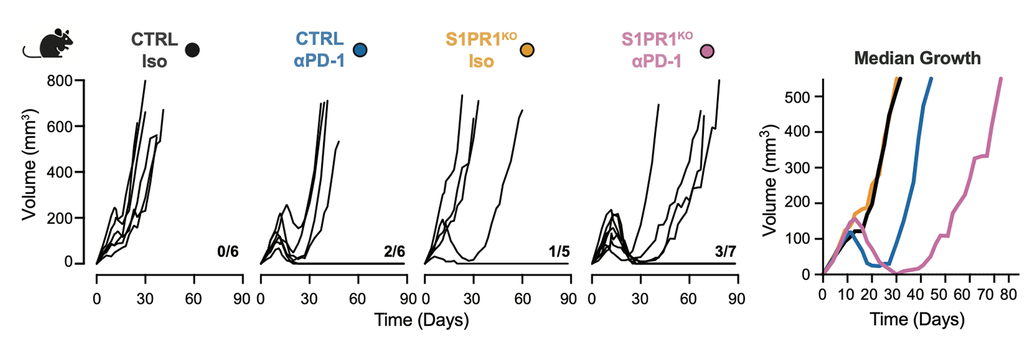

We are in the infancy of a field.

## Why might you do this?

Reason 2: Reverse-engineer something that is hard to observe

[figure not shown]

Reason 3: Learning about evolution’s design principles - some functional output, and some parameter. Why did evolution choose this value? “Teleology”

[figure not shown]

## Modeling is bi-directional

[figure not shown]